# PROJECTO FFMS

# DATA COVERAGE

## YEARS covered

```
       Greece Italy Portugal Spain
  1974     20     0        0     0
  1975      2     0        0     0
  1976      5    22       19     0
  1977     22     1        5    20
  1978      5    24       48     5
  1979      0    51       17    24
  1980     27    59       15    22
  1981     23    29       34    28
  1982     12    56        4    19
  1983      1    30       17     0
  1984     14     3        3     0
  1985     36     2       19     6
  1986     11    30        0    17
  1987     15    56       17     0
```

[output cut: 39 more lines]

SPAIN NAs

```
[1] id_min  name    port_ch begin
<0 rows> (or 0-length row.names)
```

## CABINET DESIGN

### port_type (long period)

```
            Greece Italy Portugal Spain
  HoG           20    36       25    16
  ViceHoG       16    13        7    47
  M_special      0     0       78     4
  M            693   829      422   364
  M_wP          41    98        0     0
```

### port_typeCOUNTRY (long period)

You can ignore this. This is a variable to capture country specifity

```
                            Greece Italy Portugal Spain
  HoG                            0     0       25     0
  M                              0     0      422     0
  Ministério Adjunto             0     0       27     0
  Ministério da Presidência      0     0       16     0
  Ministério do Estado           0     0       35     0
  Vice PM                        0     0        7     0
  <NA>                         770   976        0   431
```

### port_core (long/short period)

```
          Greece Italy Portugal Spain
  core       154    70      132   103
  no_core    616   224      400   328
  <NA>         0   682        0     0
```

```
          Greece Italy Portugal Spain
  core        81    68       77    55
  no_core    253   219      190   151
```

### port_field_AggA (long/short period)

```
               Greece Italy Portugal Spain
  HoG              21    12       25    16
  ViceHoG           0     0        0     0
  coordination     82    16       48    41
  macro           226   107      135   124
  economy         280    82      184   126
  social          161    76      140   124
  other             0     0        0     0
  <NA>              0   683        0     0
```

```
               Greece Italy Portugal Spain
  HoG              10    12       12     8
  ViceHoG           0     0        0     0
  coordination     29    16       30    14
  macro           103   105       66    60
  economy         115    81       82    58
  social           77    73       77    66
  other             0     0        0     0
```

## PARTISANSHIP

### partisan_lit (long period)

```
               Greece Italy Portugal Spain
  non_partisan     88   124      186    89
  partisan        682   852      346   342
  Sum             770   976      532   431
```

```
               Greece Italy Portugal Spain
  non_partisan   11.4  12.7     35.0  20.6
  partisan       88.6  87.3     65.0  79.4
  Sum           100.0 100.0    100.0 100.0
```

short

```
               Greece Italy Portugal Spain
  non_partisan     56    63       96    57
  partisan        278   224      171   149
  Sum             334   287      267   206
```

```
               Greece Italy Portugal Spain
  non_partisan   16.8  22.0     36.0  27.7
  partisan       83.2  78.0     64.0  72.3
  Sum           100.0 100.0    100.0 100.0
```

### party_weight (long/short period)

```
       Greece Italy Portugal Spain
  no      447   129      272   228
  yes     323   164      260   203
  <NA>      0   683        0     0
```

```
      Greece Italy Portugal Spain
  no     182   124      124   113
  yes    152   163      143    93
```

### party_executive (long/short period)

```
       Greece Italy Portugal Spain
  no       88   623      369   234
  yes       2   353      161   197
  <NA>    680     0        2     0
```

```
       Greece Italy Portugal Spain
  no       56   223      180   119
  yes       2    64       87    87
  <NA>    276     0        0     0
```

### partyness_kind (long/short period)

```
                Greece Italy Portugal Spain
  fast-hierarch      0     2        0     0
  HIGH-RANK        306   426      209   184
  junior-leader      0     0        3     0
  LEADER            17    24       33    17
  LOW-RANK         357   391       97   141
  newcomer           0     9        4     0
  NON-PARTISAN      90   114      116    87
  shadow             0     3       70     2
  sympathizer        0     7        0     0
```

```
                Greece Italy Portugal Spain  Sum
  fast-hierarch      0     2        0     0    2
  HIGH-RANK        140   137      119    81  477
  junior-leader      0     0        3     0    3
  LEADER            12    24       19    10   65
  LOW-RANK         126    53       27    58  264
  newcomer           0     8        3     0   11
  NON-PARTISAN      56    55       42    55  208
  shadow             0     3       54     2   59
  sympathizer        0     5        0     0    5
  Sum              334   287      267   206 1094
```

partyness_kind vs partisan_lit

SEGOV[which(SEGOV$partyness_kind=="NON-PARTISAN" & SEGOV$partisan_lit==“partisan”), c(“id_min”,“country_ch”,“gov_ch”, “name”, “partyMin”, “partyness_kind”)]

SEGOV[which(SEGOV$partyness_kind=="HIGH-RANK" & SEGOV$partisan_lit==“non_partisan”), c(“country_ch”, “gov_ch”, “name”, “partyMin”, “partyness_kind”)]

SEGOV[which(SEGOV$partyness_kind=="LEADER" & SEGOV$partisan_lit==“non_partisan”), c(“country_ch”, “gov_ch”, “name”, “partyMin”, “partyness_kind”)]

### GP_rank (long/short period)

```
               Greece Italy Portugal Spain
  NON-PARTISAN     90   124      186    89
  LOW-RANK        357   400      101   141
  HIGH-RANK       323   452      245   201
```

short

```
               Greece Italy Portugal Spain
  NON-PARTISAN     56    63       96    57
  LOW-RANK        126    61       30    58
  HIGH-RANK       152   163      141    91
  Sum             334   287      267   206
```

## POLITICNESS

### politicness (long/short period)

```
        Greece Italy Portugal Spain
  none      38    55      106    85
  some      84    55      261    49
  ample    214   183      165   297
  <NA>     434   683        0     0
  Sum      770   976      532   431
```

```
        Greece Italy Portugal Spain
  none      38    54       60    53
  some      84    52       84    10
  ample    212   181      123   143
  Sum      334   287      267   206
```

## JOB EXPERTISE

### expertise_Prof (long/short period)

```
        Greece Italy Portugal Spain
  none     131    91      113   212
  some     130    72      184     6
  ample     73   130      235   213
  <NA>     436   683        0     0
  Sum      770   976      532   431
```

```
        Greece Italy Portugal Spain
  none     131    90       53    92
  some     130    70       80     6
  ample     73   127      134   108
  Sum      334   287      267   206
```

## MANAGERIAL EXPERTISE

### expertise_Manag (long/short period)

```
        Greece Italy Portugal Spain
  none      63    34       77   234
  some     121   136      228    13
  ample    150   123      227   184
  <NA>     436   683        0     0
  Sum      770   976      532   431
```

```
        Greece Italy Portugal Spain
  none      63    32       22   125
  some     121   134      103    13
  ample    150   121      142    68
  Sum      334   287      267   206
```

## ACADEMIC

### edu_field1 (long/short period)

```
                   Greece Italy Portugal Spain
  military              2     1       14     3
  law                 135   471      209   247
  economic             63   146      106    73
  management            0     0        2     0
  engineering          39    13      120    28
  medicine             28    36        9    14
  social sciences      30    73       34    19
  natural sciences      1     7        4    18
  formal sciences      14    10        9     0
  humanities           18    75       17    13
  other                 3     7        0     3
  none                  1    86        8    13
  <NA>                436    51        0     0
  Sum                 770   976      532   431
```

```
                   Greece Italy Portugal Spain
  military              2     1        0     0
  law                 135   103      119   114
  economic             63    43       65    38
  management            0     0        1     0
  engineering          39     6       33     9
  medicine             28    15        7    13
  social sciences      30    44       24    10
  natural sciences      1     0        2     5
  formal sciences      14     3        3     0
  humanities           18    24        9     7
  other                 3     6        0     3
  none                  1    42        4     7
  Sum                 334   287      267   206
```

### edu_field2 (long/short period)

```
                   Greece Italy Portugal Spain
  military              0     0        0     0
  law                  69    17       68    61
  economic             56    18       65    65
  management            0     0       14     0
  engineering          12     4       31     9
  medicine              4    10       10     4
  social sciences      63     2       29    23
  natural sciences      0     0        1    14
  formal sciences       6     3       15     1
  humanities            8     3       10     5
  other                13    13        0     1
  none                103   265      289   248
  <NA>                436   641        0     0
  Sum                 770   976      532   431
```

```
                   Greece Italy Portugal Spain
  military              0     0        0     0
  law                  69    16       42    25
  economic             56    18       34    36
  management            0     0        8     0
  engineering          12     4       15     1
  medicine              4    10        8     3
  social sciences      63     2       20    18
  natural sciences      0     0        1     3
  formal sciences       6     3        8     1
  humanities            8     3        5     4
  other                13    13        0     1
  none                103   218      126   114
  Sum                 334   287      267   206
```

### edu_level (long/short period)

```
            Greece Italy Portugal Spain
  none           0     0        0     0
  primary        0     0        0     4
  secondary      1    43        8     8
  higher         0    63        0     0
  graduate     126   769      322   240
  post-grad    105    32       58    57
  phd          102    27      144   122
  <NA>         436    42        0     0
  Sum          770   976      532   431
```

```
            Greece Italy Portugal Spain
  none           0     0        0     0
  primary        0     0        0     1
  secondary      1     1        4     5
  higher         0    41        0     0
  graduate     126   187      133   108
  post-grad    105    32       38    41
  phd          102    26       92    51
  Sum          334   287      267   206
```

### level_related (long/short period)

```
                   Greece Italy Portugal Spain
  no_related          231   193      210   201
  graduate_related     30    61      182   127
  postgrad_related     23    22       46    29
  phd_related          50    17       94    74
  <NA>                436   683        0     0
  Sum                 770   976      532   431
```

```
                   Greece Italy Portugal Spain
  no_related          231   190       93    96
  graduate_related     30    59       85    63
  postgrad_related     23    22       29    19
  phd_related          50    16       60    28
  Sum                 334   287      267   206
```

### edu_field_related (constructed)

### expertise_Acad (constructed)

### expertise_Acad (long/short period)

```
        Greece Italy Portugal Spain
  none     232   235      210   202
  some      30    62      216   144
  ample     72    38      106    85
  <NA>     436   641        0     0
  Sum      770   976      532   431
```

```
        Greece Italy Portugal Spain
  none     232   190       93    96
  some      30    60      105    70
  ample     72    37       69    40
  Sum      334   287      267   206
```

### AGE_m! (countries with NAs, short period)

```
       Spain
  <NA>     5
```

Seg[which(is.na(Seg$age) & Seg$country_ch==“Italy”), c(“id_min”,“gov_ch”,“name”, “age”)]

Seg[which(is.na(Seg$age) & Seg$country_ch==“Greece”), c(“id_min”,“gov_ch”,“name”, “age”)]

### woman (countries with NAs , short period)

```
< table of extent 2 x 0 >
```

## TYPOLOGY (short period)

### Inclusive strategy (`f4_PE_s`)

```
             Greece Italy Portugal Spain
  amateur         6     4       10    10
  expert         50    62       86    47
  specialist    182   152      155    97
  generalist     96    69       16    52
  Sum           334   287      267   206
```

```
[1] name           gov_ch         partisan_lit   expertise_Acad expertise_Prof
[6] f4_PE_s        f4_PE_a
<0 rows> (or 0-length row.names)
```

### Restrictive strategy (`f4_PE_a`)

```
             Greece Italy Portugal Spain
  amateur        95    45       40    30
  expert         87    79       86    85
  specialist     33    54       66    32
  generalist    119   109       75    59
  Sum           334   287      267   206
```

### Mix strategy (`f4_PE_mix`)

```
             Greece Italy Portugal Spain
  amateur        13    11       30    12
  expert         43    55       66    45
  specialist     77    78       86    72
  generalist    201   143       85    77
  Sum           334   287      267   206
```

## 2.2 The Typology

## The Typology of Ministerial Profiles

### inclusive

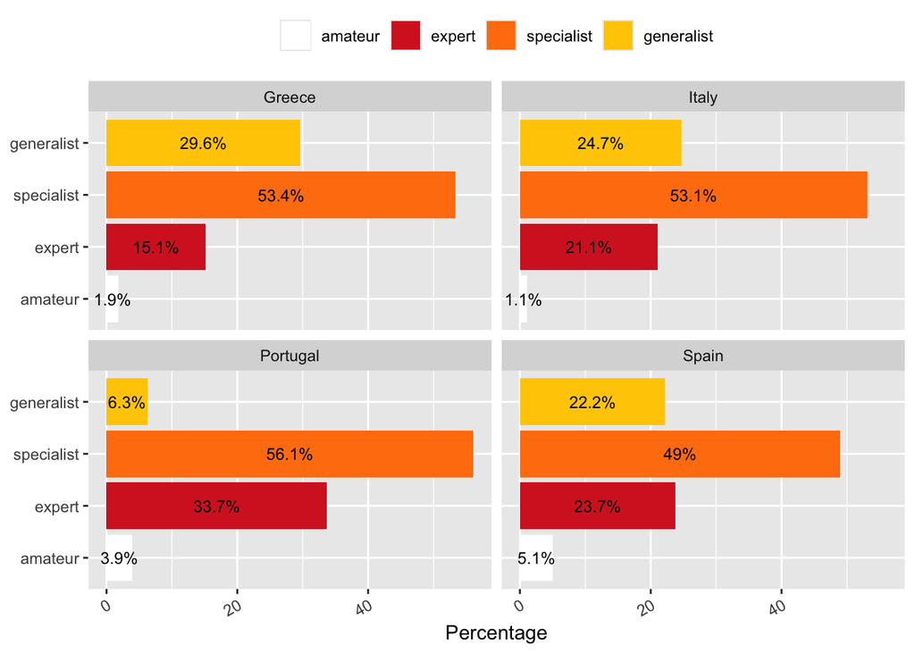

### restrictive

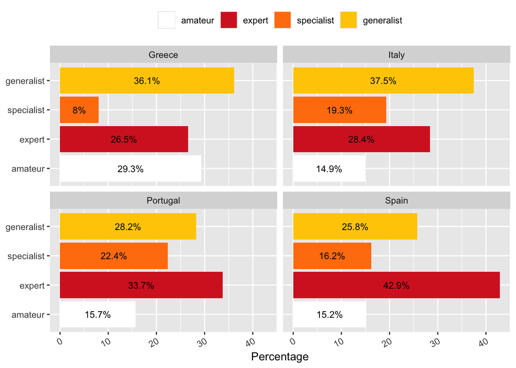

### mix

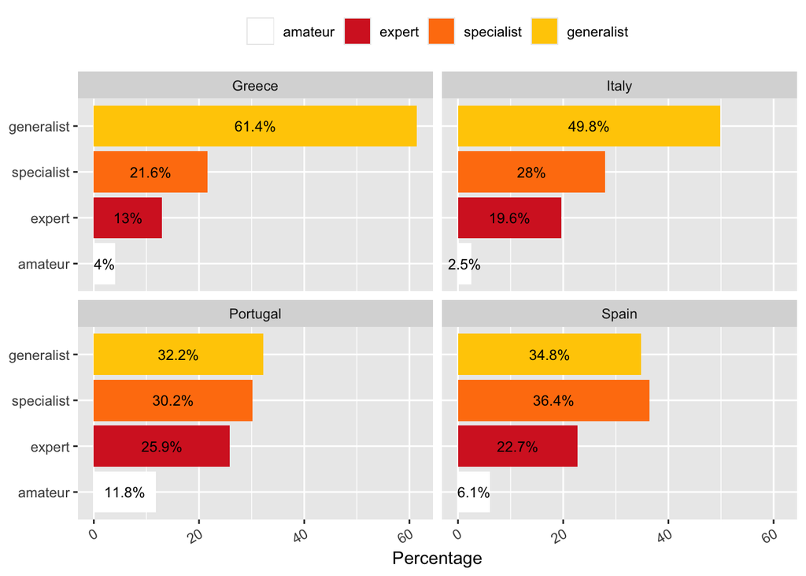